# BigDataAssignment1

Błażej Wiórek

3/30/2020

## Zadanie 1

Zadania polega na wizualizacji aproksymacji wartości $P(Z > t)$, gdzie $Z \sim N(0, 1)$ oraz $t\in \mathbb{R}$ to pewien próg powyżej którego będę odrzucał hipoteze zerową. Aproksymacja ma następującą postać:

$$\frac{\phi(t)}{t}(1-\frac{1}{t^2}) \leq \mathbb{P}(Z > t) \leq \frac{\phi(t)}{t}$$

Dowód tego, że $\mathbb{P} (Z > t) \leq \frac{\phi(t)}{t}$:

Jako, że $\mathbb{P} (Z > t) =\frac{1}{\sqrt{2\pi}} \int_t^{\infty} e^{\frac{x^2}{2}} dx$, to obszar całkowania ma postać: $x \geq t$ z czego otrzymuje, że $\frac{x}{t} \geq 1$. Mogę teraz zapisać, że $\frac{1}{\sqrt{2\pi}} \int_t^{\infty} e^{\frac{x^2}{2}} dx \leq \frac{1}{\sqrt{2\pi}t} \int_t^{\infty} e^{\frac{x^2}{2}} dx$, co daje w wyniku teze.

Dowód ograniczenia dolnego jest prosty ale żmudny dlatego zostanie pominięty.

Dodatkowo można się spodziewać, że:

- Wraz ze wzrostem t, $P(Z > t)$ maleje
- $lim_{t \rightarrow0^+} \frac{\phi(t)}{t} = + \infty$
- $lim_{t \rightarrow0^+} \frac{\phi(t)}{t}(1-\frac{1}{t^2}) = 0$

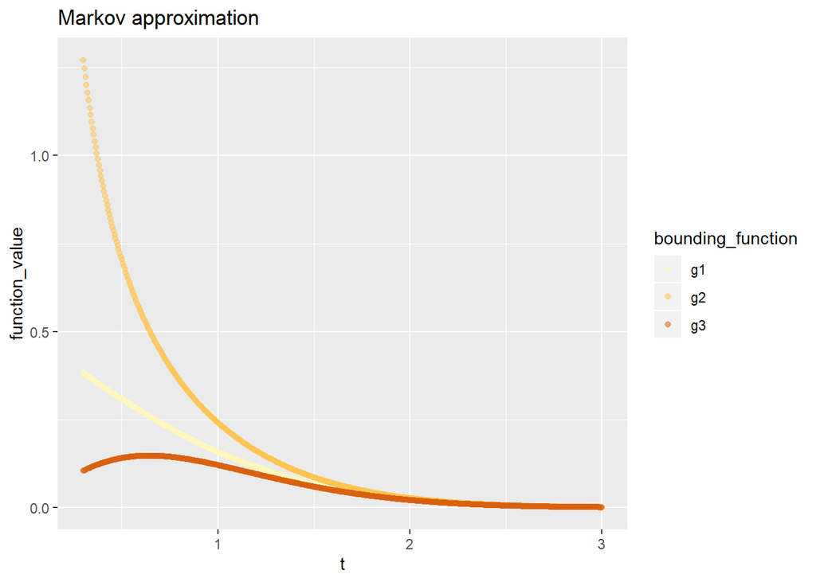

```r
create_approximation <- function(t) {
    cdf_t <- pnorm(t)
    pdf_t <- dnorm(t)
    g1 <- 1-cdf_t
    g2 <- pdf_t/t
    g3 <- dnorm(t) * (t / (1 + t^2))
    data.frame(t=t, g1=g1, g2=g2, g3=g3, `g1/g2`=g1/g2, `g1/g3`=g1/g3)
}

t <- seq(0.3, 3, length.out = 500)
markov_bounds_df <- dplyr::bind_rows(lapply(t, create_approximation))
markov_bounds_df.markov_long <- markov_bounds_df %>%
                                select(1:4) %>%
                                gather(key="bounding_function",
                                       value="function_value",
                                       c("g1", "g2", "g3"))

markov_bounds_plot <- ggplot(markov_bounds_df.markov_long, aes(x=t, y=function_value, color=bounding_function)) +
                      geom_point(alpha=0.5) +
                      scale_color_brewer(palette="YlOrBr") +
                      ggtitle("Markov approximation")
markov_bounds_plot
```

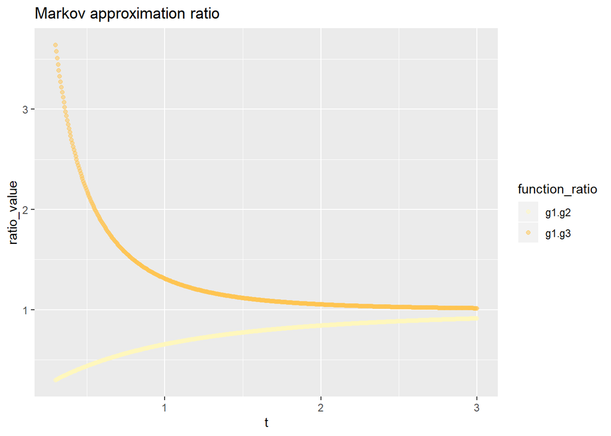

```r
markov_bounds_df.ratio_long <- markov_bounds_df %>%
                               select(c(1,5,6)) %>%
                               gather(key="function_ratio",
                                      value="ratio_value",
                                      c("g1.g2", "g1.g3"))

ratio_bounds_plot <- ggplot(markov_bounds_df.ratio_long, aes(x=t, y=ratio_value, color=function_ratio)) +
                     geom_point(alpha=0.5) +
                     scale_color_brewer(palette="YlOrBr") +
                     ggtitle("Markov approximation ratio")
ratio_bounds_plot
```

## Zadanie 2

Dla ustalonego poziomu $\alpha$ można pokazać, że $|z(\frac{\alpha}{n})| \approx \sqrt{2logn}$. Wynika z tego, że jeśli wartość $\alpha$ jest ustalona a $n \rightarrow \infty$, to $|z(\frac{\alpha}{n})|$ rośnie w tempie $\sqrt{2logn}$.

Inne (dokładniejsze) przybliżenie ma postać: $|z(\frac{\alpha}{n})| \approx \sqrt{B(1 - \frac{logB}{B})}$, $B = 2log(\frac{2p}{\alpha}) - log(2\pi)$. Jest ono jednak znacznie mniej użyteczne ze względu na to, że zależy ono od parametru $\alpha$.

Przyjmuje następujące oznaczenia: $g_1(\alpha, p)=\Phi^{-1}(1 - \frac{\alpha}{2p})$, $g_2(p)=\sqrt{2logn}$, $g_3(\alpha, p)=\sqrt{B(1 - \frac{logB}{B})}$.

```r
create_row <- function(p, alpha) {
    g1 <- qnorm(1 - alpha / (2 * p))
    cp <- sqrt(2 * log(p))
    B <- 2*log(2*p / alpha) - log(2 * pi)
    g2 <- sqrt(B - log(B))
    data.frame(p=p, alpha=alpha, g1=g1, cp=cp, g2=g2, `g1/g2`=g1/g2, `g1/cp`=g1/cp)
}

p <- exp(seq(log(10^2), log(10^9), length.out = 1000))
alpha <- c(0.01, 0.1, 0.5)
alpha <- rep(alpha, each=length(p))
p <- rep(p, 3)

df <- dplyr::bind_rows(mapply(create_row, p=p, alpha=alpha, SIMPLIFY = FALSE))
df.raw_functions <- df %>% select(1:5) %>% gather(key="f", value="value", c("g1", "cp", "g2"))
df.ratios <- df %>% select(c(1,2,6,7)) %>% gather(key="f", value="value", c("g1.g2", "g1.cp"))
```

Można zaobserwować, że przybliżenie kwantyla $|z(\frac{\alpha}{n})|$ za pomocą $\sqrt{B(1 - \frac{logB}{B})}$ jest nierozróżnialne na poniższym wykresie. Z drugiej strony dokładność przybliżenia za pomocą $\sqrt{2logn}$ jest zależna od poziomu istotności $\alpha$.

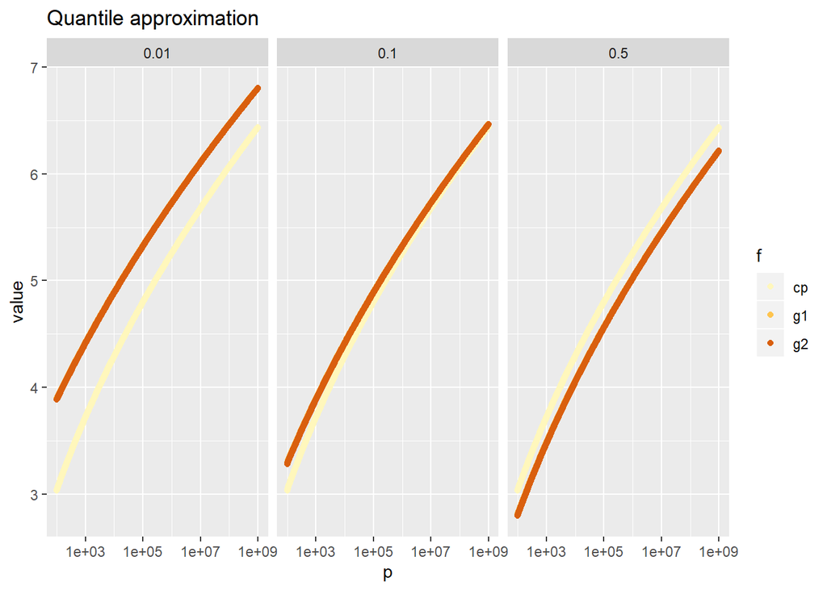

```r
raw_functions_plot <- ggplot(df.raw_functions, aes(x=p, y=value, color=f)) +
                      geom_point() +
                      scale_color_brewer(palette="YlOrBr") +
                      scale_x_log10() +
                      facet_grid(.~alpha) +
                      ggtitle("Quantile approximation")
raw_functions_plot
```

Powyższe obserwacje znajdują swoje potwierdzenie w poniższych wykresach. Można zauważyć, że $\forall p \frac{g_1(\alpha, p)}{g_2(\alpha, p)} \approx 1$, natomiast $\frac{g_1(\alpha, p)}{c(p)} \rightarrow 1$ oraz funkcja jest rosnąca lub malejąca w zależności od $\alpha$.

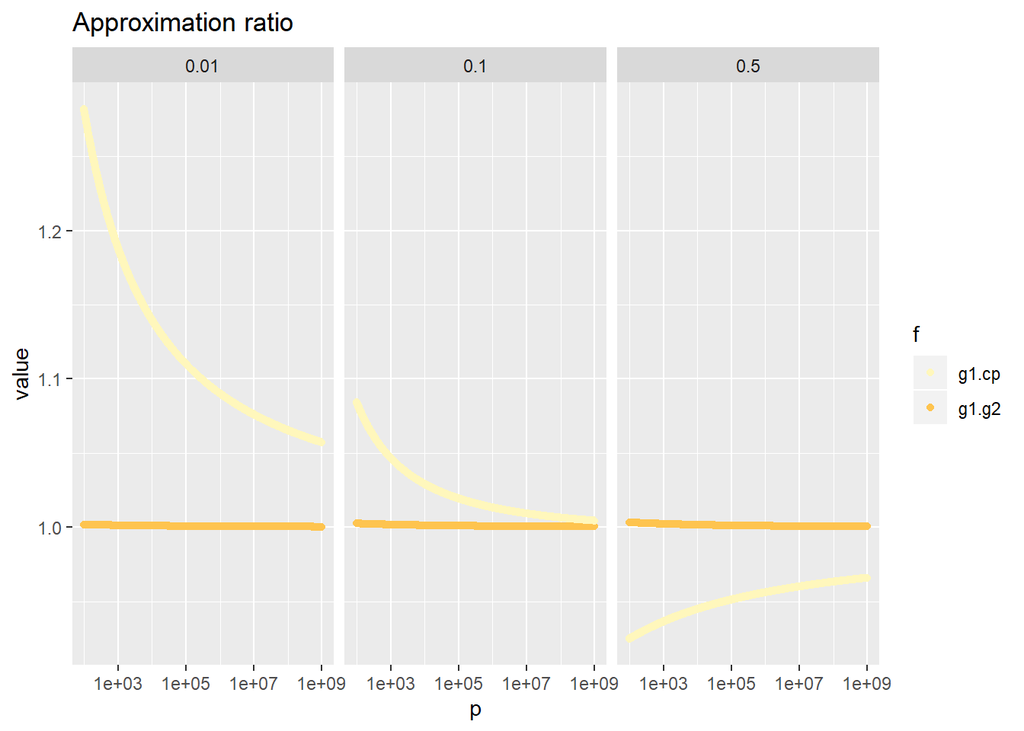

```r
ratios_plot <- ggplot(df.ratios, aes(x=p, y=value, color=f)) +
    geom_point() +
    scale_color_brewer(palette="YlOrBr") +
    scale_x_log10() +
    facet_grid(.~alpha) +
    ggtitle("Approximation ratio")

ratios_plot
```

## Zadanie 3

Celem zadania jest wizualne przedstawienie tego, że $\frac{max(|y_i|)}{\sqrt{2logk}} \rightarrow 1$. Oznacza to tyle, że aby sygnał był wykryty przez test Bonferroniego, jego siła musi przekroczyć granicę $\sqrt{2logk}$.

```r
create_row <- function(k, trajectory_id) {
    p = rnorm(k)
    M_k <- max(p[1:k])
    g_k <- sqrt(2 * log(k))
    data.frame(k=k, M_k=M_k, `M_k/g_k` = M_k/g_k, trajectory=trajectory_id)
}

create_k <- function(max_power) {10 ^ (1:max_power)}

create_trajectories <- function(k_v) {
    trajectories <- list()
    for (k in k_v) {
        trajectory_id <- paste("n=", k)
        trajectories[[k]] = dplyr::bind_rows(lapply(rep(k, 5), create_row, trajectory_id=trajectory_id))
    }
    dplyr::bind_rows(trajectories)

}

k_v <- 10^(1:8)
trajectories <- create_trajectories(k_v)
g_k_df = data.frame(x=k_v, g_k=sqrt(2 * log(k_v)))
```

Czerwone trójkąty wyznaczają granice $\sqrt{2logk}$. Można zaobserwować, że dla kolejnych trajektorii postaci $M_k = max_{i \in \{1, ..., k\}}|Y_K|$, gdzie $Y_k \ \sim N(0, 1)$ oraz $k \in \{10, 10^2, ...,10^8\}$ wartości $M_k$ są zazwyczaj mniejsze niż $\sqrt{2logk}$.

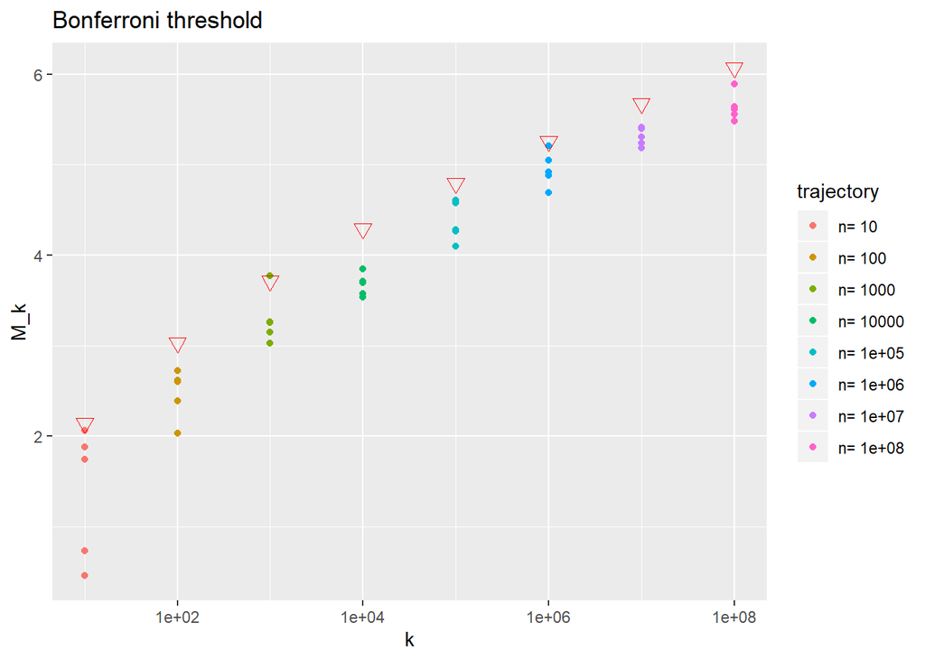

```r
t_plot <- ggplot() +
    geom_point(data=trajectories, aes(x=k, y=M_k, color=trajectory)) +
    geom_point(data=g_k_df, aes(x=x, y=g_k), shape=25, color="red", size=3) +
    scale_x_log10() +
    ggtitle("Bonferroni threshold")
plot(t_plot)
```

Wykres poniżej pozwala zwizualizować stwierdzenie z wprowadzenia do zadania tzn: $\frac{max(|y_i|)}{\sqrt{2logk}} \rightarrow 1$.

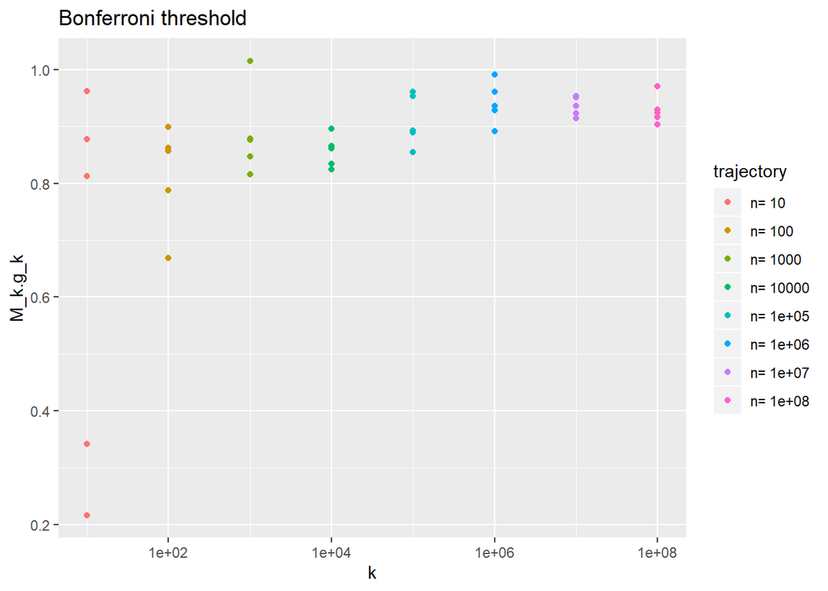

```r
gk_mk_plot <- ggplot(trajectories, aes(x=k, y=M_k.g_k, color=trajectory)) +
              geom_point() +
              scale_x_log10() +
              ggtitle("Bonferroni threshold")
plot(gk_mk_plot)
```

## Zadanie 4

Zadanie polega na wyestymowaniu mocy testu Bonferroniego i testu chi-square dla następujących scenariuszy:

1. $\mu_1 = 1.2\sqrt{2logp}, \mu_2 = ... =\mu_p = 0$
2. $\mu_1 = ... = \mu_{1000} = 0.15\sqrt{2 logp}, \mu_{1001} = ... =\mu_p = 0$

Nie trudno zorientować się, że test pierwszy jest typowym scenariuszem dla testu Bonferroniego jako, że mam pojedynczy sygnał który spełnia założenie $\mu_i > (1 + \epsilon)\sqrt{2 logp}$. Drugi przypadek jest przykładem mającym pokazać zastosowanie testu chi-square jako, że mam wiele relatywnie słabych sygnałów.

```r
bonferroni_test <- function(X, alpha) {
    n <- length(X)
    bonferroni_thresh <- qnorm(1 - alpha / (2 * n))
    # TRUE if H0 rejected
    sum(X > bonferroni_thresh) > 0
}

chi_sqare_test <- function(X, alpha) {
    n <- length(X)
    T_stat <- abs((sum(X^2) - n)/sqrt(2*n))
    # TRUE if H0 rejected
    T_stat > qnorm(1 - alpha/2)
}

test_sparse <- function(i, sample_size, alpha) {
    X <- rnorm(sample_size)
    X[1] <- 1.2 * sqrt(2* log(sample_size))
    bonferroni <- bonferroni_test(X, alpha)
    chi_square <- chi_sqare_test(X, alpha)
    data.frame(bonferroni=bonferroni, chi_square=chi_square)
}

test_dense <- function(i, sample_size, non_zero_mu, alpha) {
    X <- rnorm(sample_size)
    X[1:non_zero_mu] <- 0.15 * sqrt(2 * log(sample_size))
    bonferroni <- bonferroni_test(X, alpha)
    chi_square <- chi_sqare_test(X, alpha)
    data.frame(bonferroni=bonferroni, chi_square=chi_square)
}

sample_size = 1000
rep = 5000
sparse_res <- dplyr::bind_rows(lapply(1:rep, test_sparse, sample_size=sample_size, alpha=0.05))
dense_res <- dplyr::bind_rows(lapply(1:rep, test_dense, sample_size=sample_size, non_zero_mu=1000, alpha=0.05))
```

Moc wyestymowana dla podpunktu a):

```r
sparse_power <- colSums(sparse_res)/rep
sparse_power
```

```
## bonferroni chi_square
##      1.000      0.074
```

Zgodnie z założeniami moc testu Bonferroniego wynosi niemal 1, natomiast moc testu chi-square jest bardzo niska.

Moc wyestymowana dla podpunktu b):

```r
dense_power <- colSums(dense_res)/rep
dense_power
```

```
## bonferroni chi_square
##          0          1
```

Zgodnie z założeniami mam sytuacje odwrotną niż w podpunkcie a) tzn. test Bonferroniego nie był w stanie odrzucić globalnej hipotezy zerowej w żadnym z powtórzeń eksperyment, co wynika ze zbyt małej siły sygnału.